# Intersections of Adversity & Neurodiversity: Adverse Childhood Experiences’ Association to Mental Health & the Buffering Role of Flourishing

Author: Adrián Medina

Date: October 5, 2024

# Project Overview

This repository contains files relevant to a study investigating the relationship between adverse childhood experiences (ACEs) and mental health outcomes in children with neurodevelopmental disorders (NDDs), such as Autism Spectrum Disorder (ASD) and ADHD. The study specifically examines the moderating role of child flourishing behaviors—curiosity in learning, emotional control, and task persistence—on the effects of ACEs on mental health outcomes.

**Study Design**:  
The study utilizes data from the National Survey of Children’s Health (NSCH), focusing on children aged 6-17 with reported neurodevelopmental issues (N = 44,776, M<sub>Age</sub> = 12.2). This cross-sectional analysis examines ACE exposure and its impact on three primary mental health outcomes: anxiety, depression, and behavioral issues. The moderating role of child flourishing behaviors is assessed using interaction terms in logistic regression models.

**Data Collection**:  
Key variables collected include:

- **Adverse Childhood Experiences (ACEs)**: Derived from parent-reported experiences such as exposure to violence, household dysfunction, and discrimination.
- **Mental Health Outcomes**: Parent-reported diagnoses of anxiety, depression, and behavioral problems, confirmed by health care providers or educators.
- **Child Flourishing Metrics**: Based on parent-reported behaviors such as curiosity in learning, emotional control, and task persistence, which were used to develop a Child Flourishing Index (CFI).

**Analytic Approach**:  
The primary analytic approach involved logistic regression models to assess the association between ACEs and mental health outcomes, with interaction terms to explore the moderating effect of child flourishing. Key covariates include age, sex, race/ethnicity, and socioeconomic status.

**Goals**:  
The study aims to:

- **Examine the dose-response relationship** between the number of ACEs and risks of mental health challenges in neurodivergent children.
- **Identify the protective role of child flourishing behaviors**, offering insights into resilience-promoting interventions for this vulnerable population.

**Tip**

For detailed information on the dataset variables, refer to the [**NSCH Data Dictionary**](https://www.census.gov/data-tools/demo/uccb/nschdict?s_keyword=).

# Code Workflow

1. Data Frame Initialization
2. Analytic Data Preparation
3. Frequencies & Descriptive Statistics
4. Inferential Statistics

# Data Frame Initialization

Set up the R environment by configuring the CRAN repository, installing essential packages, setting the base path, and loading the primary dataset into the local environment.

**Expand Code**

```r
# Set CRAN repository for consistent package installation
options(repos = c(CRAN = "http://cran.rstudio.com/"))

# Install and load the pacman package for efficient package management
if (!require(pacman)) install.packages("pacman")
library(pacman)

# Use p_load function to install (if necessary) and load packages
p_load(dplyr, tidyr, tidyverse, knitr, ggplot2, Hmisc, broom, stats, kableExtra, webshot2)

# Specify the 'base_path' where you can find your data files, ASSUMING they're in the same directory, & set it as WD
base_path <- "~/GitHub/Adversity-Neurodiversity/data_files"
setwd(base_path)

# Load primary data file
neurodivergent_data <- read_csv("neurodivergent_data.csv")
```

**1**

See details under the `important` callout below!

**Data Extraction & Filtering (Archived Code)**

The file being used for these analyses is a subset of a “master” file containing the compiled contents of the data releases from the National Survey on Child Health’s 2016-2022 cycles. The master file is nearly 500 MB (0.5 GB) in size, making it cumbersome to process in real-time. For efficiency and ease of analysis, I am using a smaller subset that contains only the relevant data. This subset was generated using the data extraction and filtering process detailed in the archived code below, in an effort to maintain transparency and ensure reproducibility of the workflow.

**Expand Code**

```r
# Define the path to the dataset
data_path <- "~/Downloads/Data2_2016to2022.csv"
Data2_2016to2022 <- read.csv(data_path)

# Prepare project data: Select specific variables, create 'neurodivergent' variable, & filter data based on age and neurodivergent status
neurodivergent_data <- Data2_2016to2022 %>%
  select(year, fpl, fpl_mean, sc_age_years, sc_hispanic_r, sc_race_r, sc_sex, higrade_tvis, k2q35a, k2q35c, k2q38a,
         k2q38c, k2q30a, k2q30c, k2q36a, k2q36c, k2q60a, k2q60c, k2q37a, k2q37c, downsyn, downsyn_desc,
         k2q31a, k2q31c, k2q61a, cerpals_desc, k2q33a, k2q33b, k2q33c, k2q32a, k2q32b, k2q32c, k2q34a, k2q34b, k2q34c,
         ace1, ace3, ace4, ace5, ace6, ace7, ace8, ace9, ace10, ace11, ace12, k6q71_r, k7q85_r, k7q84_r) %>%
  # Creating 'neurodivergent' variable as NSCH does not explicitly inquire about neurodivergent status.
  # Using a list of diagnoses provided by NSCH to define neurodivergent individuals.
  mutate(neurodivergent = if_else(k2q35a == 1 | k2q38a == 1 | k2q36a == 1 | k2q60a == 1 |
                                  k2q37a == 1 | k2q30a == 1 | downsyn == 1 |
                                  k2q31a == 1 | k2q61a == 1, 1, 0)) %>%
  # Filter data to include only individuals aged 6 or above and identified as neurodivergent
  filter(sc_age_years >= 6, neurodivergent == 1)

# Resulting filtered data to be used for further analysis
write.csv(neurodivergent_data, "neurodivergent_data.csv")
```

# Analytic Data Preparation

Set up recoding of variables by transforming ‘ace1’ into a dichotomous variable, calculating the Childhood Flourishing Index (CFI), and categorizing total ACE counts. Recode education, income, sex, race/ethnicity, and CFI into categorical factors for analysis.

**Expand Code**

```r
# Recode 'ace1' to dichotomous variable based on analytic specifications
neurodivergent_data$ace1_recode <- ifelse(neurodivergent_data$ace1 %in% c(2, 3, 4), 1,
                                          ifelse(neurodivergent_data$ace1 == 1, 0, NA))

# Calculate the Childhood Flourishing Index (CFI) based on Bethell et al. (2019) criteria
neurodivergent_data <- neurodivergent_data %>%
  mutate(CFI = rowSums(select(., k6q71_r, k7q85_r, k7q84_r) == 1, na.rm = TRUE),
         # Total ACE count for each child excluding missing values
         ace_total = rowSums(select(., ace1_recode, ace3:ace12) == 1, na.rm = TRUE),
         # Categorize total ACEs for further analysis
         ace_counts = cut(ace_total, breaks = c(-1, 0, 1, 3, Inf),
                          labels = c('1', '2', '3', '4'), right = TRUE),
         # Recode education, income, sex, race/ethnicity variables into categorical factors
         highgrade_tvis_cat = case_when(
           higrade_tvis == 1 ~ "Less than high school",
           higrade_tvis == 2 ~ "High school (including vocational)",
           higrade_tvis == 3 ~ "Some college or associate degree",
           higrade_tvis == 4 ~ "College degree or higher",
           TRUE ~ NA_character_
         ),
         fpl_cat = case_when(
           fpl %in% c(50:99) | fpl_mean < 100 ~ "Less than 100%",
           fpl %in% c(100:199) | fpl_mean < 200 ~ "100% to 199%",
           fpl %in% c(200:299) | fpl_mean < 300 ~ "200% to 299%",
           fpl %in% c(300:399) | fpl_mean < 400 ~ "300% to 399%",
           fpl %in% c(400:999) | fpl_mean < 999 ~ "400% or greater",
           TRUE ~ NA_character_
         ),
         sc_sex_cat = case_when(
           sc_sex == 1 ~ "Male",
           sc_sex == 2 ~ "Female",
           TRUE ~ NA_character_
         ),
         race = case_when(
           sc_race_r == 1 ~ "White",
           sc_race_r == 2 ~ "Black",
           sc_race_r == 3 ~ "American Indian or Alaska Native",
           sc_race_r %in% 4:5 ~ "Asian, Native Hawaiian, or Pacific Islander",
           sc_race_r %in% 6:7 ~ "Other or mixed race",
           TRUE ~ NA_character_
         ),
         ethnicity = case_when(
           sc_hispanic_r == 1 ~ "Hispanic/Latino",
           sc_hispanic_r == 2 ~ "Non-Hispanic/Latino",
           TRUE ~ NA_character_
         ),
         sc_race_cat = case_when(
           race %in% c("White") & ethnicity == "Non-Hispanic/Latino" ~ "Non-Hispanic White",
           race %in% c("Black") & ethnicity == "Non-Hispanic/Latino" ~ "Non-Hispanic Black or African American",
           race %in% c("American Indian or Alaska Native") & ethnicity == "Non-Hispanic/Latino" ~ "Non-Hispanic American Indian or Alaska Native",
           race %in% c("Asian, Native Hawaiian or Pacific Islander") & ethnicity == "Non-Hispanic/Latino" ~ "Non-Hispanic Asian, Native Hawaiian or Pacific Islander",
           race %in% c("Other or mixed race") & ethnicity == "Non-Hispanic/Latino" ~ "Non-Hispanic Other or mixed race",
           ethnicity == "Hispanic/Latino" ~ "Hispanic or Latino of any race",
           TRUE ~ NA_character_
         ),
         # Recode CFI into dichotomous variable
         CFI_dich = case_when(
           CFI == 3 ~ "1",
           CFI %in% 0:2 ~ "0",
           TRUE ~ NA_character_
         )
  )
```

**1**

`ace1` is originally coded by NSCH as a frequency measure, but it’s needed as indicative variable of presence like the other `ace#` variables.

**2**

Combining data manipulation functions into single `dplyr` chain to optimize code execution.

# Frequencies & Descriptive Statistics

**Expand Code**

```r
# Creating frequency tables for specific diagnostic outcomes to assess their distribution in the dataset
freq_k2q33b <- table(neurodivergent_data$k2q33b == 1, useNA="ifany")
freq_k2q32b <- table(neurodivergent_data$k2q32b == 1, useNA="ifany")
freq_k2q34b <- table(neurodivergent_data$k2q34b == 1, useNA="ifany")

# Combine frequency tables into a single data frame for easy viewing
freq_table <- data.frame(
  Diagnosis = c("Anxiety", "Depression", "Behavioral Problems"),
  Count = c(freq_k2q33b["TRUE"], freq_k2q32b["TRUE"], freq_k2q34b["TRUE"])
)

# Use knitr::kable to format the frequency table for better readability in the output document
knitr::kable(freq_table, caption = "Frequency of Specific Diagnostic Outcomes")
```

Frequency of Specific Diagnostic Outcomes

| Diagnosis | Count |
| --- | --- |
| Anxiety | 13725 |
| Depression | 6289 |
| Behavioral Problems | 13535 |

**Expand Code**

```r
# Count the number of subjects with a CFI score of 3 using a logical condition, as this is considered 'Flourishing.'
num_subjects_cfi_3 <- sum(neurodivergent_data$CFI == 3, na.rm = TRUE)
cat("Number of Subjects Flourishing (CFI Score of 3):", num_subjects_cfi_3, "\n")
```

```
Number of Subjects Flourishing (CFI Score of 3): 3265
```

**Expand Code**

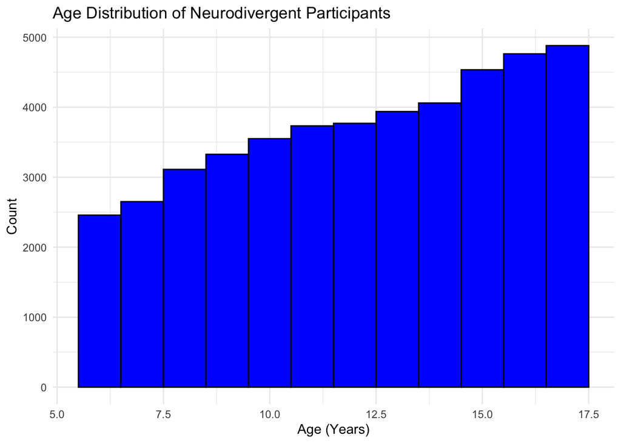

```r
# Histogram of ages for neurodivergent participants
ggplot(neurodivergent_data, aes(x = sc_age_years)) +
  geom_histogram(binwidth = 1, fill = "blue", color = "black") +
  labs(title = "Age Distribution of Neurodivergent Participants", x = "Age (Years)", y = "Count") +
  theme_minimal()
```

**Expand Code**

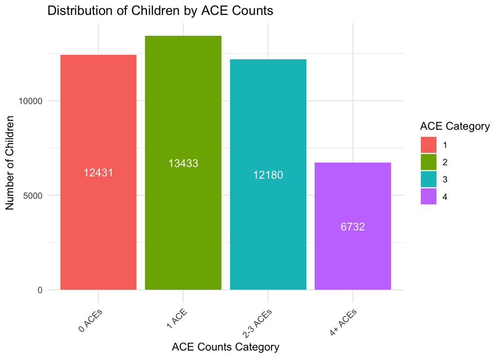

```r
# Bar plot of ACE counts categories
ggplot(neurodivergent_data, aes(x = factor(ace_counts), fill = factor(ace_counts))) +
  geom_bar() +
  geom_text(stat = 'count', aes(label = ..count..), position = position_stack(vjust = 0.5), color = "white") +
  labs(x = "ACE Counts Category", y = "Number of Children", fill = "ACE Category",
       title = "Distribution of Children by ACE Counts") +
  scale_x_discrete(labels = c('1' = "0 ACEs", '2' = "1 ACE", '3' = "2-3 ACEs", '4' = "4+ ACEs")) +
  theme_minimal() +
  theme(axis.text.x = element_text(angle = 45, hjust = 1))
```

**Expand Code**

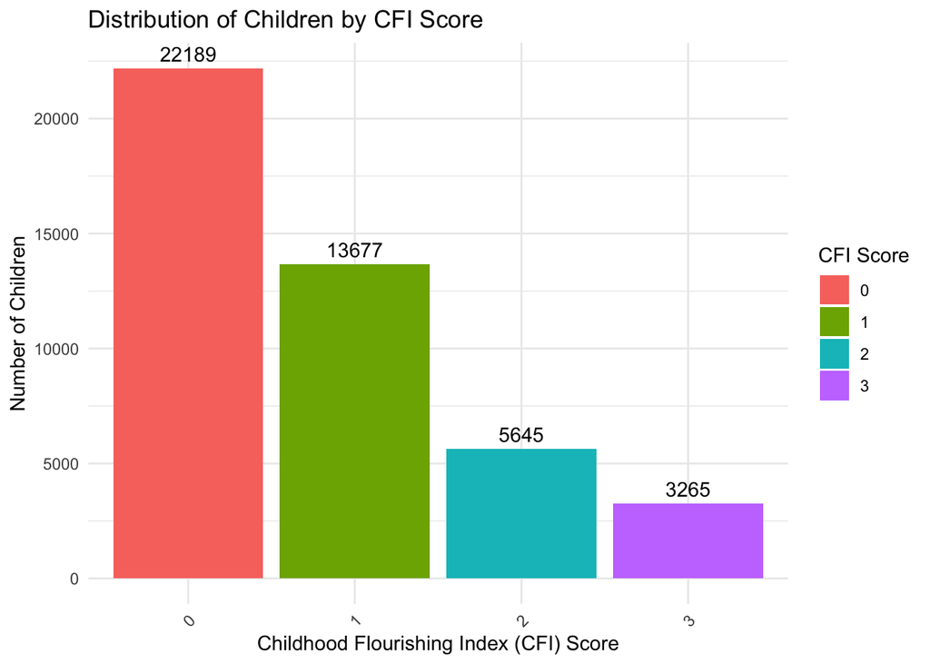

```r
# Bar plot of CFI counts categories
ggplot(neurodivergent_data, aes(x = factor(CFI), fill = factor(CFI))) +
  geom_bar() +
  geom_text(stat = 'count', aes(label = ..count..), vjust = -0.5, color = "black") +
  labs(x = "Childhood Flourishing Index (CFI) Score",
       y = "Number of Children",
       fill = "CFI Score",
       title = "Distribution of Children by CFI Score") +
  scale_x_discrete(labels = c('0' = "0", '1' = "1", '2' = "2", '3' = "3")) +
  theme_minimal() +
  theme(axis.text.x = element_text(angle = 45, hjust = 1))
```

**Expand Code**

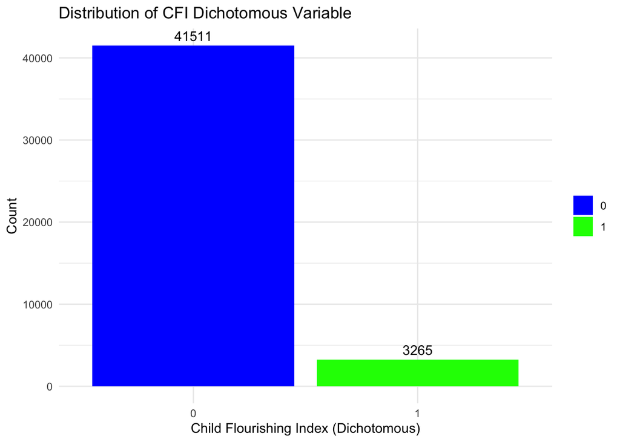

```r
# Bar plot of CFI_dich counts categories
ggplot(neurodivergent_data, aes(x = CFI_dich)) +
  geom_bar(aes(fill = CFI_dich)) +
  geom_text(stat = 'count', aes(label = ..count..), vjust = -0.5) +
  scale_fill_manual(values = c("0" = "blue", "1" = "green")) +
  labs(title = "Distribution of CFI Dichotomous Variable",
       x = "Child Flourishing Index (Dichotomous)",
       y = "Count") +
  theme_minimal() +
  theme(legend.title = element_blank()) # Remove the legend title if not needed
```

**Expand Code**

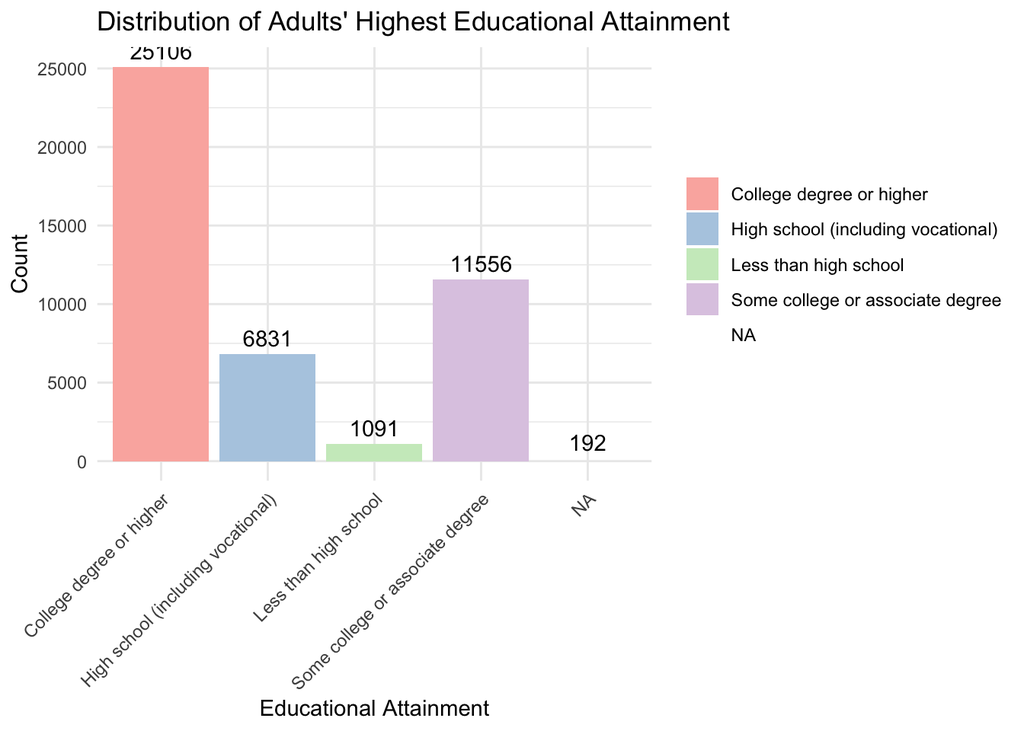

```r
# Bar plot for educational attainment counts categories
ggplot(neurodivergent_data, aes(x = highgrade_tvis_cat)) +
  geom_bar(aes(fill = highgrade_tvis_cat)) +
  geom_text(stat = 'count', aes(label = ..count..), vjust = -0.5) +
  scale_fill_brewer(palette = "Pastel1") +
  labs(title = "Distribution of Adults' Highest Educational Attainment",
       x = "Educational Attainment",
       y = "Count") +
  theme_minimal() +
  theme(axis.text.x = element_text(angle = 45, hjust = 1), legend.title = element_blank())
```

**Expand Code**

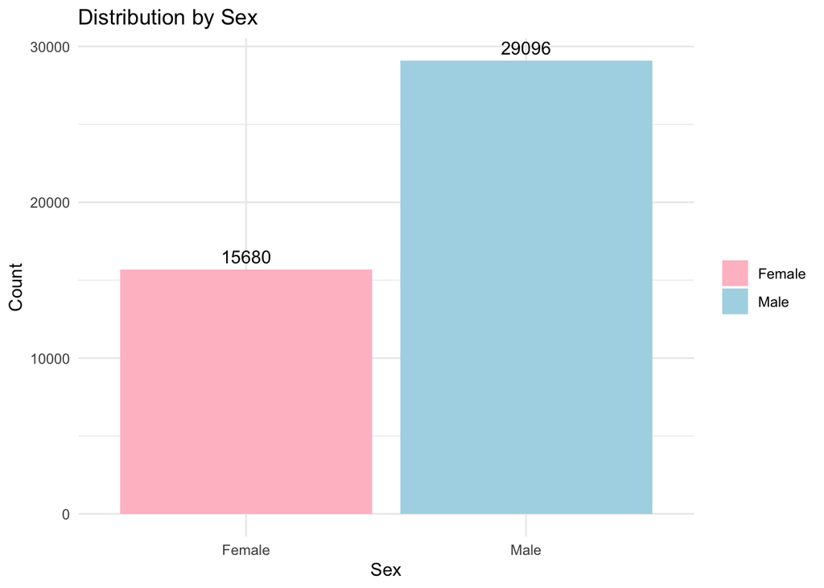

```r
# Bar plot for sex counts distribution
ggplot(neurodivergent_data, aes(x = sc_sex_cat)) +
  geom_bar(aes(fill = sc_sex_cat)) +
  geom_text(stat = 'count', aes(label = ..count..), vjust = -0.5) +
  scale_fill_manual(values = c("Male" = "lightblue", "Female" = "pink")) +
  labs(title = "Distribution by Sex",
       x = "Sex",
       y = "Count") +
  theme_minimal() +
  theme(legend.title = element_blank())
```

**Expand Code**

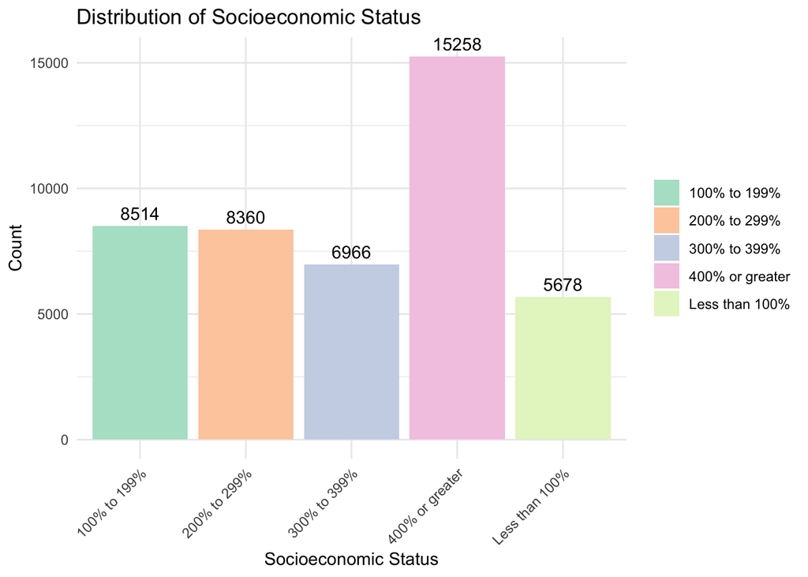

```r
#Bar plot for SES counts categories
ggplot(neurodivergent_data, aes(x = fpl_cat)) +
  geom_bar(aes(fill = fpl_cat)) +
  geom_text(stat = 'count', aes(label = ..count..), vjust = -0.5) +
  scale_fill_brewer(palette = "Pastel2") +
  labs(title = "Distribution of Socioeconomic Status",
       x = "Socioeconomic Status",
       y = "Count") +
  theme_minimal() +
  theme(axis.text.x = element_text(angle = 45, hjust = 1), legend.title = element_blank())
```

**Expand Code**

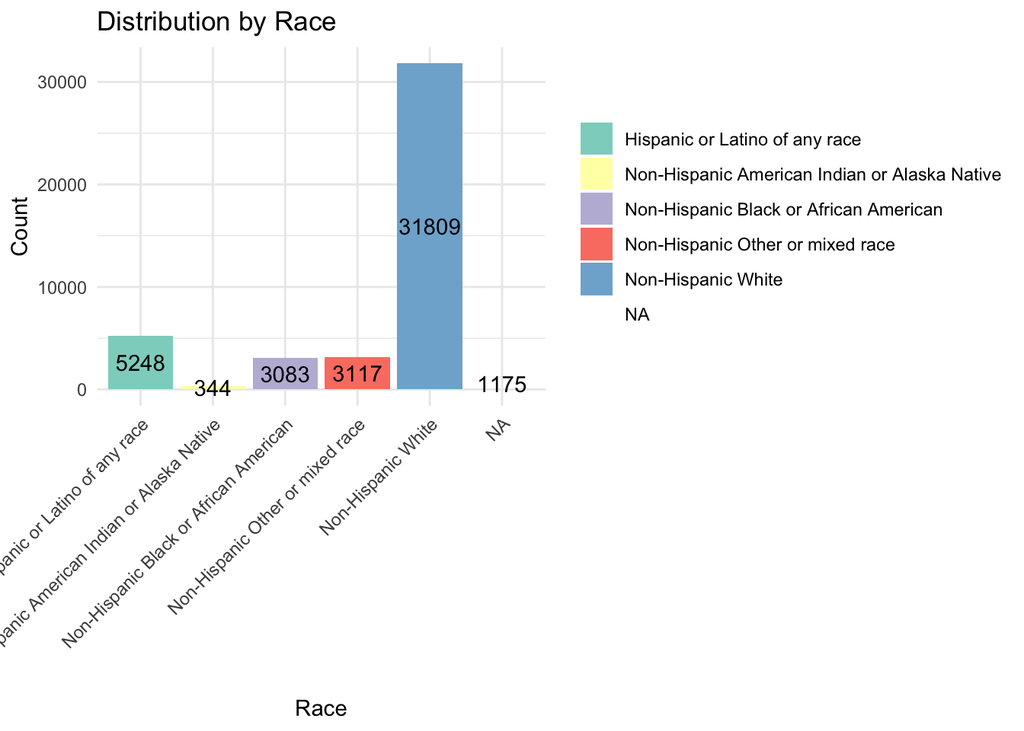

```r
# Bar plot for race counts categories
ggplot(neurodivergent_data, aes(x = sc_race_cat)) +
  geom_bar(aes(fill = sc_race_cat)) +
  geom_text(stat = 'count', aes(label = ..count..), position = position_stack(vjust = 0.5)) +
  scale_fill_brewer(palette = "Set3") +
  labs(title = "Distribution by Race",
       x = "Race",
       y = "Count") +
  theme_minimal() +
  theme(axis.text.x = element_text(angle = 45, hjust = 1), legend.title = element_blank())
```

**Expand Code**

```r
# Calculate mean and standard deviation of age for neurodivergent participants
age_stats <- neurodivergent_data %>%
  filter(neurodivergent == 1) %>%
  summarise(
    Mean_Age = mean(sc_age_years, na.rm = TRUE),
    SD_Age = sd(sc_age_years, na.rm = TRUE)
  )

# Print the statistics using a nicely formatted table
knitr::kable(age_stats, caption = "Age Statistics of Neurodivergent Participants")
```

Age Statistics of Neurodivergent Participants

| Mean_Age | SD_Age |
| --- | --- |
| 12.17523 | 3.375748 |

**Expand Code**

```r
# Calculate prevalence (%) of diagnoses among subject sample
variables <- c("k2q31a", "k2q35a", "k2q38a", "k2q30a", "k2q36a", "k2q60a", "k2q37a", "downsyn", "k2q61a")
variable_names <- c("ADHD", "Autism/ASD", "Tourette’s Syndrome", "Learning Disability",
                    "Development Delay", "Intellectual Disability",
                    "Speech/Other Language Disorder", "Down Syndrome", "Cerebral Palsy")

# Pre-calculate total respondents to avoid repeated computation
total_respondents <- colSums(!is.na(neurodivergent_data[variables]))

# Vectorized prevalence calculation
prevalences <- colSums(neurodivergent_data[variables] == 1, na.rm = TRUE) / total_respondents * 100
prevalence_table <- data.frame(Diagnosis = variable_names, Prevalence = prevalences)

# Display prevalence data in a table
knitr::kable(prevalence_table, caption = "Prevalence of Neurodivergent Conditions")
```

Prevalence of Neurodivergent Conditions

|  | Diagnosis | Prevalence |
| --- | --- | --- |
| k2q31a | ADHD | 58.9175975 |
| k2q35a | Autism/ASD | 15.2625563 |
| k2q38a | Tourette’s Syndrome | 1.6302642 |
| k2q30a | Learning Disability | 39.6132560 |
| k2q36a | Development Delay | 31.7615419 |
| k2q60a | Intellectual Disability | 5.6693867 |
| k2q37a | Speech/Other Language Disorder | 36.2469766 |
| downsyn | Down Syndrome | 0.9816886 |
| k2q61a | Cerebral Palsy | 1.4784403 |

**Expand Code**

```r
# Prepare the data for cross-tabulations
neurodivergent_data <- neurodivergent_data %>%
  mutate(
    k2q32b = factor(k2q32b, levels = c(2, 1), labels = c("No", "Yes")),
    k2q33b = factor(k2q33b, levels = c(2, 1), labels = c("No", "Yes")),
    k2q34b = factor(k2q34b, levels = c(2, 1), labels = c("No", "Yes")),
    CFI_dich = factor(CFI_dich, levels = c(0, 1), labels = c("Not flourishing", "Flourishing")),
    ace_counts = factor(ace_counts, levels = c(1, 2, 3, 4), labels = c("0", "1", "2 or 3", "4+"))
  )

# Create the cross-tabulations
table_data <- neurodivergent_data %>%
  select(k2q32b, k2q33b, k2q34b, CFI_dich, ace_counts) %>%
  pivot_longer(cols = c(k2q32b, k2q33b, k2q34b, CFI_dich), names_to = "Condition", values_to = "Status") %>%
  group_by(Condition, Status, ace_counts) %>%
  summarise(n = n(), .groups = "drop") %>%
  group_by(Condition, ace_counts) %>%
  mutate(percent = n / sum(n) * 100) %>%
  pivot_wider(names_from = ace_counts, values_from = c(n, percent), names_sep = ", ")

# Format the table for presentation using 'kable' and 'kableExtra'
knitr::kable(table_data, format = "latex", caption = "Frequency and Percentage of Psychopathology and Flourishing across ACEs Categories") %>%
  kableExtra::kable_styling("striped", full_width = FALSE)
```

[output not shown]

# Inferential Statistics

**Expand Code**

```r
# Subsetting data for regression analysis and recoding variables to factors for proper model fitting
analysis_data <- neurodivergent_data %>%
  select(ace_counts, CFI_dich, k2q33b, k2q32b, k2q34b, sc_race_cat, sc_sex_cat, fpl_cat, highgrade_tvis_cat, sc_age_years) %>%
  mutate(
    # Recoding ACE counts into a factor with ordered levels indicating the number of adverse childhood experiences
    ace_counts = factor(ace_counts, levels = c("0", "1", "2-3", "4+")),
    # Recoding the Childhood Flourishing Index into a binary factor indicating flourishing status
    CFI_dich = factor(CFI_dich, levels = c("Not flourishing", "Flourishing")),
    # Recoding binary outcomes for behavioral issues, depression, and anxiety into factors
    k2q33b = factor(k2q33b, levels = c("No", "Yes")),
    k2q32b = factor(k2q32b, levels = c("No", "Yes")),
    k2q34b = factor(k2q34b, levels = c("No", "Yes")),
    # Recoding race categories into factors to ensure proper representation in statistical tests
    sc_race_cat = factor(sc_race_cat, levels = c("Non-Hispanic White", "Non-Hispanic Black or African American", "Non-Hispanic American Indian or Alaska Native", "Non-Hispanic Asian, Native Hawaiian or Pacific Islander", "Non-Hispanic Other or mixed race", "Hispanic or Latino of any race")),
    # Recoding sex categories into a factor to control for gender differences in the analysis
    sc_sex_cat = factor(sc_sex_cat, levels = c("Male", "Female")),
    # Recoding federal poverty level categories into factors to reflect socioeconomic status
    fpl_cat = factor(fpl_cat, levels = c("Less than 100%", "100% to 199%", "200% to 299%", "300% to 399%", "400% or greater")),
    # Recoding educational attainment into factors, categorized by the highest level achieved
    highgrade_tvis_cat = factor(highgrade_tvis_cat, levels = c("Less than high school", "High school (including vocational)", "Some college or associate degree", "College degree or higher"))
  )

# Output the structure of the newly created dataset to verify the changes and ensure correct data types
str(analysis_data)
```

```
tibble [44,776 × 10] (S3: tbl_df/tbl/data.frame)
 $ ace_counts        : Factor w/ 4 levels "0","1","2-3",..: 1 NA 4 2 2 NA 4 1 2 4 ...
 $ CFI_dich          : Factor w/ 2 levels "Not flourishing",..: 2 1 1 1 1 1 1 1 1 2 ...
 $ k2q33b            : Factor w/ 2 levels "No","Yes": NA NA NA NA NA NA NA 1 NA NA ...
 $ k2q32b            : Factor w/ 2 levels "No","Yes": NA NA NA NA NA NA NA NA NA NA ...
 $ k2q34b            : Factor w/ 2 levels "No","Yes": 2 2 2 NA NA NA 2 NA NA NA ...
 $ sc_race_cat       : Factor w/ 6 levels "Non-Hispanic White",..: 1 1 2 1 2 1 1 1 1 1 ...
 $ sc_sex_cat        : Factor w/ 2 levels "Male","Female": 1 1 1 1 1 1 2 2 1 2 ...
 $ fpl_cat           : Factor w/ 5 levels "Less than 100%",..: 5 4 1 1 2 4 1 5 3 4 ...
 $ highgrade_tvis_cat: Factor w/ 4 levels "Less than high school",..: 4 3 4 2 4 4 2 4 3 3 ...
 $ sc_age_years      : num [1:44776] 9 10 17 9 9 17 16 9 13 15 ...
```

**Expand Code**

```r
# Fit basic logistic regression models for multiple outcomes and compute odds ratios and confidence intervals
outcomes <- list("Anxiety" = neurodivergent_data$k2q33b, "Depression" = neurodivergent_data$k2q32b, "Behavioral Problems" = neurodivergent_data$k2q34b)
models <- list()
or <- list()
ci <- list()

for (outcome_name in names(outcomes)) {
  outcome <- outcomes[[outcome_name]]

  # Fit model without interaction
  model <- glm(outcome ~ ace_counts + sc_race_cat + sc_sex_cat + fpl_cat + highgrade_tvis_cat + sc_age_years,
               family = binomial, data = analysis_data)
  models[[paste(outcome_name, "No Interaction", sep = " ")]] <- model

  # Fit model with interaction
  model_interaction <- glm(outcome ~ ace_counts * CFI_dich + sc_race_cat + sc_sex_cat + fpl_cat + highgrade_tvis_cat + sc_age_years,
                           family = binomial, data = analysis_data)
  models[[paste(outcome_name, "With Interaction", sep = " ")]] <- model_interaction

  # Calculate odds ratios and confidence intervals, ensuring model convergence
  if (!is.null(coef(model))) {
    or[[outcome_name]] <- list(
      "No Interaction" = exp(coef(model)),
      "With Interaction" = exp(coef(model_interaction))
    )
    ci[[outcome_name]] <- tryCatch({
      list(
        "No Interaction" = exp(confint(model)),
        "With Interaction" = exp(confint(model_interaction))
      )
    }, error = function(e) return(list(error = "Failed to compute confidence intervals")))
  } else {
    or[[outcome_name]] <- list(error = "Model did not converge")
  }
}

# Print model summaries and calculated odds ratios and confidence intervals
lapply(models, summary)
```

```
$`Anxiety No Interaction`

Call:
glm(formula = outcome ~ ace_counts + sc_race_cat + sc_sex_cat +
    fpl_cat + highgrade_tvis_cat + sc_age_years, family = binomial,
    data = analysis_data)

Coefficients:
                                                         Estimate Std. Error
(Intercept)                                               2.46689    0.31239
ace_counts1                                               0.23752    0.08656
ace_counts4+                                              0.57807    0.10429
sc_race_catNon-Hispanic Black or African American        -0.26340    0.17073
sc_race_catNon-Hispanic American Indian or Alaska Native -0.60251    0.32673
sc_race_catNon-Hispanic Other or mixed race              -0.07856    0.14818
sc_race_catHispanic or Latino of any race                -0.23806    0.11379
sc_sex_catFemale                                          0.30898    0.07618
fpl_cat100% to 199%                                      -0.30822    0.14684
fpl_cat200% to 299%                                      -0.12085    0.15655
fpl_cat300% to 399%                                      -0.33437    0.15904
fpl_cat400% or greater                                   -0.25825    0.15145
highgrade_tvis_catHigh school (including vocational)      0.14118    0.27867
highgrade_tvis_catSome college or associate degree        0.10257    0.27207
highgrade_tvis_catCollege degree or higher                0.13765    0.27303
sc_age_years                                             -0.02206    0.01145
                                                         z value Pr(>|z|)
(Intercept)                                                7.897 2.86e-15 ***
ace_counts1                                                2.744  0.00607 **
ace_counts4+                                               5.543 2.98e-08 ***
sc_race_catNon-Hispanic Black or African American         -1.543  0.12289
sc_race_catNon-Hispanic American Indian or Alaska Native  -1.844  0.06517 .
sc_race_catNon-Hispanic Other or mixed race               -0.530  0.59601
sc_race_catHispanic or Latino of any race                 -2.092  0.03642 *
sc_sex_catFemale                                           4.056 4.99e-05 ***
fpl_cat100% to 199%                                       -2.099  0.03581 *
fpl_cat200% to 299%                                       -0.772  0.44014
fpl_cat300% to 399%                                       -2.102  0.03551 *
fpl_cat400% or greater                                    -1.705  0.08817 .
highgrade_tvis_catHigh school (including vocational)       0.507  0.61242
highgrade_tvis_catSome college or associate degree         0.377  0.70619
```

[output cut: 291 more lines]

```
highgrade_tvis_catCollege degree or higher                -1.718 0.085810 .
sc_age_years                                             -16.580  < 2e-16 ***
ace_counts1:CFI_dichFlourishing                           -1.222 0.221716
ace_counts4+:CFI_dichFlourishing                          -2.289 0.022051 *
---
Signif. codes:  0 '***' 0.001 '**' 0.01 '*' 0.05 '.' 0.1 ' ' 1

(Dispersion parameter for binomial family taken to be 1)

    Null deviance: 8577.3  on 10525  degrees of freedom
Residual deviance: 8145.0  on 10507  degrees of freedom
  (34250 observations deleted due to missingness)
AIC: 8183

Number of Fisher Scoring iterations: 5
```

**Expand Code**

```r
lapply(or, function(x) knitr::kable(x, caption = "Odds Ratios"))
```

```
$Anxiety


<table class="kable_wrapper">
<caption>Odds Ratios</caption>
<tbody>
  <tr>
   <td>

|                                                         |          x|
|:--------------------------------------------------------|----------:|
|(Intercept)                                              | 11.7857485|
|ace_counts1                                              |  1.2681054|
|ace_counts4+                                             |  1.7825975|
|sc_race_catNon-Hispanic Black or African American        |  0.7684367|
|sc_race_catNon-Hispanic American Indian or Alaska Native |  0.5474380|
|sc_race_catNon-Hispanic Other or mixed race              |  0.9244498|
|sc_race_catHispanic or Latino of any race                |  0.7881522|
|sc_sex_catFemale                                         |  1.3620401|
|fpl_cat100% to 199%                                      |  0.7347501|
|fpl_cat200% to 299%                                      |  0.8861684|
|fpl_cat300% to 399%                                      |  0.7157856|
|fpl_cat400% or greater                                   |  0.7724040|
|highgrade_tvis_catHigh school (including vocational)     |  1.1516315|
|highgrade_tvis_catSome college or associate degree       |  1.1080101|
|highgrade_tvis_catCollege degree or higher               |  1.1475791|
|sc_age_years                                             |  0.9781779|

 </td>
   <td>

|                                                         |          x|
|:--------------------------------------------------------|----------:|
|(Intercept)                                              | 12.5185834|
|ace_counts1                                              |  1.2678791|
|ace_counts4+                                             |  1.7073862|
|CFI_dichFlourishing                                      |  0.3800652|
|sc_race_catNon-Hispanic Black or African American        |  0.7642781|
|sc_race_catNon-Hispanic American Indian or Alaska Native |  0.5412261|
|sc_race_catNon-Hispanic Other or mixed race              |  0.9071809|
```

[output cut: 118 more lines]

```
|fpl_cat100% to 199%                                      |  0.7810911|
|fpl_cat200% to 299%                                      |  0.7631209|
|fpl_cat300% to 399%                                      |  0.6831885|
|fpl_cat400% or greater                                   |  0.6822890|
|highgrade_tvis_catHigh school (including vocational)     |  0.8879151|
|highgrade_tvis_catSome college or associate degree       |  0.8223207|
|highgrade_tvis_catCollege degree or higher               |  0.6938750|
|sc_age_years                                             |  0.8587421|
|ace_counts1:CFI_dichFlourishing                          |  0.6199218|
|ace_counts4+:CFI_dichFlourishing                         |  0.3279527|

 </td>
  </tr>
</tbody>
</table>
```

**Expand Code**

```r
lapply(ci, function(x) knitr::kable(x, caption = "Confidence Intervals"))
```

```
$Anxiety


<table class="kable_wrapper">
<caption>Confidence Intervals</caption>
<tbody>
  <tr>
   <td>

|                                                         |     2.5 %|     97.5 %|
|:--------------------------------------------------------|---------:|----------:|
|(Intercept)                                              | 6.5300551| 22.3270750|
|ace_counts1                                              | 1.0700830|  1.5025982|
|ace_counts4+                                             | 1.4541130|  2.1888791|
|sc_race_catNon-Hispanic Black or African American        | 0.5562421|  1.0879853|
|sc_race_catNon-Hispanic American Indian or Alaska Native | 0.3012026|  1.0976916|
|sc_race_catNon-Hispanic Other or mixed race              | 0.6976386|  1.2484482|
|sc_race_catHispanic or Latino of any race                | 0.6333166|  0.9897371|
|sc_sex_catFemale                                         | 1.1741066|  1.5828780|
|fpl_cat100% to 199%                                      | 0.5488241|  0.9766600|
|fpl_cat200% to 299%                                      | 0.6500094|  1.2016321|
|fpl_cat300% to 399%                                      | 0.5223016|  0.9748913|
|fpl_cat400% or greater                                   | 0.5712467|  1.0348595|
|highgrade_tvis_catHigh school (including vocational)     | 0.6466730|  1.9402949|
|highgrade_tvis_catSome college or associate degree       | 0.6290698|  1.8390602|
|highgrade_tvis_catCollege degree or higher               | 0.6503946|  1.9084426|
|sc_age_years                                             | 0.9563629|  1.0002951|

 </td>
   <td>

|                                                         |     2.5 %|     97.5 %|
|:--------------------------------------------------------|---------:|----------:|
|(Intercept)                                              | 6.9031002| 23.8272720|
|ace_counts1                                              | 1.0636752|  1.5110357|
|ace_counts4+                                             | 1.3872481|  2.1045415|
|CFI_dichFlourishing                                      | 0.2383877|  0.6284932|
|sc_race_catNon-Hispanic Black or African American        | 0.5528631|  1.0827403|
|sc_race_catNon-Hispanic American Indian or Alaska Native | 0.2974903|  1.0861277|
|sc_race_catNon-Hispanic Other or mixed race              | 0.6842168|  1.2257445|
```

[output cut: 118 more lines]

```
|fpl_cat100% to 199%                                      |  0.6233664|  0.9751944|
|fpl_cat200% to 299%                                      |  0.6047063|  0.9597630|
|fpl_cat300% to 399%                                      |  0.5334633|  0.8726020|
|fpl_cat400% or greater                                   |  0.5412141|  0.8561453|
|highgrade_tvis_catHigh school (including vocational)     |  0.5700447|  1.3398826|
|highgrade_tvis_catSome college or associate degree       |  0.5322834|  1.2283268|
|highgrade_tvis_catCollege degree or higher               |  0.4490296|  1.0366342|
|sc_age_years                                             |  0.8433426|  0.8742649|
|ace_counts1:CFI_dichFlourishing                          |  0.2858580|  1.3317701|
|ace_counts4+:CFI_dichFlourishing                         |  0.1248681|  0.8504686|

 </td>
  </tr>
</tbody>
</table>
```

This document was made by [Adrián Medina](https://adrian-a-medina.github.io/) as part of the [Slopen Laboratory](https://www.hsph.harvard.edu/profile/natalie-slopen/), based on the [Lumo](https://www.productive-r-workflow.com/r/bonus/lumo-quarto-template) quarto template.